# Projeto computacional de PE

## Projeto computacional de PE

1. No ficheiro de dados econ.xlsx encontra informação relativa a dados económicos dos Estados Unidos providenciados pela empresa [FRED](https://fred.stlouisfed.org/). Este conjunto de dados possui as seguintes variáveis: tempo (Data do registo); gcp (gastos de consumo pessoal, em biliões de dólares); pop (população total); tpp (taxa de poupança pessoal); ddesemp (duração mediana do desemprego, em semanas); ndesemp (número de desempregados, em milhares).

   Uma vez que as variáveis podem não ter a mesma escala, antes de construir o gráfico proceda do seguinte modo:
   1. Selecione os dados a usar.
   2. Faça a seguinte transformação aos dados associados a cada variável
      $$X_k: z_{ik}=\frac{x_{ik}-{\bar{x}_k}}{s_{x_k}},\quad i=1,2,\dots,n,$$
      onde $n$ é a dimensão da amostra, ${\bar{x}_k}$ e $s_{x_k}$ correspondem, respectivamente, à média e desvio-padrão da amostra associada à variável $X_k$.

   Submeta um ficheiro em formato PDF, com uma única página A4, que inclua:
   1. O código em `R`.

      **Nota:** no código devem também constar os comandos para leitura e seleção dos dados do ficheiro.
   2. O gráfico que achar mais adequado para analisar a evolução dessas variáveis nesse período de tempo.

#### Resolução

   ```
   library(ggplot2)
   theme_set(theme_light())
   # vars <- c("gcp", "pop")
   # ano <- 2000

   econ <- readxl::read_excel("econ.xlsx", sheet = "IndicadoresEcon")
   econ$tempo <- as.Date(econ$tempo, format = "%d-%m-%Y")
   ss <- subset(econ, tempo >= as.Date(paste0(ano, "-1-1")))
   ss$gcp <- scale(ss$gcp)
   ss$pop <- scale(ss$pop)

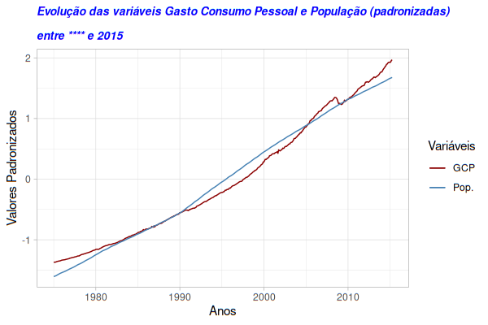

2. O ficheiro TIME_USE_24092022.csv contém uma compilação de dados enviados por diversos países para a OCDE ([Organização para a Cooperação e Desenvolvimento Económico](https://stats.oecd.org/Index.aspx?DataSetCode=TIME_USE)) sobre o tempo médio diário (em minutos) despendido pelas pessoas entre os 15 e os 64 anos em diferentes tipos de ocupações.
   1. Leia o ficheiro de dados no `R` e elimine todos os registos referentes à África do Sul (dados incompletos).
   2. Submeta um ficheiro em formato PDF com uma única página A4, que inclua, num único gráfico, dois diagramas de extremos e quantis que permitam comparar os tempos médios diários registados para **Homens** em duas ocupações distintas: **Cuidados pessoais** e **Trabalho não remunerado**.

      **Nota:** o código apresentado deve incluir os comandos para leitura e seleção dos dados do ficheiro.

#### Resolução

   ```
   library(ggplot2)
   theme_set(theme_light())

   # ocupacoes <- c("Lazer", "Trabalho remunerado ou estudo")
   # grupo <- "Mulheres" # por exemplo

   url <- 'https://web.tecnico.ulisboa.pt/~paulo.soares/pe/projeto/TIME_USE_24092022.csv'
   tempo <- read.csv(url)
   tempo <- subset(tempo, País != 'África do Sul')

   dados <- subset(tempo, Sexo == grupo & Ocupação %in% ocupacoes)

   ggplot(dados) +
     geom_boxplot(aes(Ocupação, Tempo)) +
     labs(title = paste0("Uso do tempo diário em vários países ", "(", grupo,")"),
          y = "Tempo médio (minutos)")
   ```

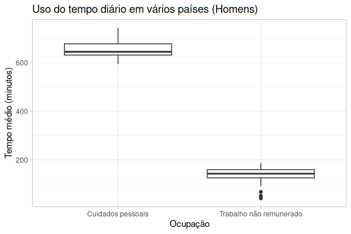

3. O ficheiro GENDER_EMP_19032023152556091.txt contém uma compilação de dados sobre emprego enviados por diversos países para a OCDE ([Organização para a Cooperação e Desenvolvimento Económico](https://stats.oecd.org/Index.aspx?DataSetCode=GENDER_EMP)).

   Com recurso ao pacote `ggplot` produza um único gráfico de barras que permita comparar os valores da variável **EMP5** (*Share of employed in part-time employment, by sex and age group*) entre homens e mulheres nos grupos etários 15–24, 25–54 e 55–64, registados em **2005** no seguinte país: **Türkiye**.

   Por simplicidade, mantenha todo o texto no gráfico em Inglês.

   Submeta um ficheiro em formato PDF com uma única página A4, que inclua:
   1. O código em `R`, que deve incluir os comandos para leitura e seleção dos dados do ficheiro.
   2. O gráfico produzido.

#### Resolução

   ```
   library(ggplot2)

   # url <- 'https://web.tecnico.ulisboa.pt/~paulo.soares/pe/projeto/GENDER_EMP_19032023152556091.txt'
   # gender <- read.delim(url, check.names = FALSE)
   # pais <- "Portugal"
   # ano <- 2010
   # variavel <- "EMP1" # por exemplo

   classes <- c("1524", "2554", "5564")
   data <- subset(gender, Country == pais & IND == variavel & SEX != 'ALL_PERSONS' & AGE %in% classes &
                  TIME == ano)
   var_desc <- data$Indicator[1]

   ggplot(data) +
     geom_col(aes(`Age Group`, Value, fill = SEX), position = "dodge") +
     labs(title = paste("Employment in", pais, "in", ano),
          subtitle = paste0(var_desc, " (", variavel, ")"),
          y = paste(variavel, "(%)")) +
     theme_linedraw()
   ```

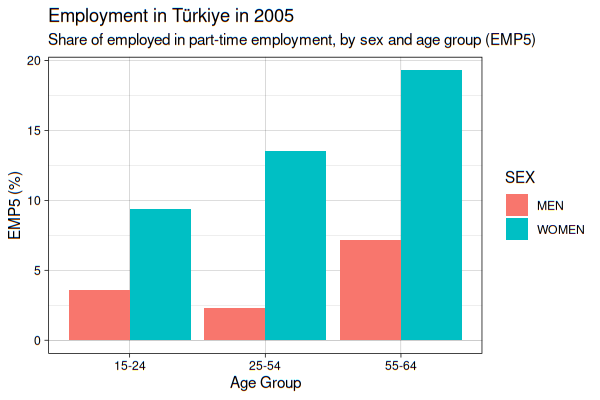

4. 1. Fixando a semente em 2300, gere uma amostra de dimensão $k = 1040$ proveniente de uma distribuição Exponencial de parâmetro $\lambda = 19$. Os valores gerados correspondem aos tempos entre acontecimentos sucessivos.
   2. Considere agora a soma sucessiva destas observações, i.e., se $x_i$ designar o $i$-ésimo valor gerado, então $s_j=\sum_{i=1}^jx_i$ é o instante de ocorrência do $j$-ésimo acontecimento. Seja $T=\lceil s_{1040} \rceil$ o menor número inteiro maior ou igual ao instante de ocorrência do último acontecimento.
   3. Divida o intervalo $]0,T]$ em intervalos de amplitude unitária e contabilize o número de acontecimentos que ocorreram em cada um desses subintervalos.
   4. Calcule a média do número de acontecimentos por subintervalo e de seguida calcule o desvio absoluto entre este valor e o valor esperado (teórico) do número de acontecimentos num subintervalo. Indique este desvio arredondado a 4 casas decimais.

#### Resolução

   ```
   # seed <- 971
   # lambda <- 12.0
   # k <- 5000

   set.seed(seed)

   inter <- rexp(k, lambda)
   arr <- cumsum(inter)
   Tk <- ceiling(arr[k])

   res <- abs(lambda - mean(table(cut(arr, breaks = 0:Tk))))
   ```

   O desvio pedido é igual a 0.4286.
5. Ensaios de Bernoulli independentes, cada um dos quais com probabilidade de sucesso $0.4$, são sucessivamente realizados. Seja $X$ o número de insucessos até ao primeiro ensaio que resulta em sucesso. A distribuição da variável aleatória $X$ é conhecida por distribuição geométrica de parâmetro $p = 0.4$, cuja função (massa) de probabilidade é dada por:

   $$f_X(x) = \begin{cases} (1-p)^x \,p, &x=0,1,2,\ldots \\
   0, &\text{caso contrário.}
   \end{cases}$$

   Podemos gerar valores de uma distribuição geométrica a partir de uma distribuição uniforme contínua usando o **método de transformação inversa**. Nesse sentido, requer-se a execução dos seguintes passos:
   1. Simula-se um valor, $u$, proveniente de uma distribuição uniforme no intervalo $]0,1[$.
   2. Se $F_X(x-1) < u \leq F_X(x)$, aceita-se $x$ como um valor simulado de $X$, onde $F_X(x)$ é a função de distribuição de $X$.

   Fixando a semente em $1139$, implemente este método de simulação estocástica repetindo os passos anteriores até obter uma amostra de dimensão $n = 1081$.

   Indique a proporção de valores simulados que são superiores à soma da média com o desvio padrão amostrais, de entre os que são superiores à respetiva média amostral. Apresente o resultado com 4 casas decimais.

#### Resolução

   ```
   # seed <- 971 #por exemplo
   # p <- 0.15
   # n <- 901

   set.seed(seed)
   u <- runif(n)

   x <- ceiling(log(1 - u) / log(1 - p)) - 1

   q1 <- sum(x > mean(x) + sd(x))
   q2 <- sum(x > mean(x))
   res <- q1 / q2
   ```

   A proporção pedida é igual a 0.3627.
6. Considere a variável aleatória $X$ que representa o primeiro algarismo de um número inteiro escrito em base decimal. Admita que $X$ possui distribuição de Benford, com função de probabilidade dada por:
   $$P(X=x)=\log_{10}\left(1+\frac{1}{x}\right), \quad x \in \{1,2,\ldots,9\}.$$
   1. Calcule a probabilidade de $X$ ser igual a $5$ ou $9$.
   2. Obtenha a fração de potências de dois no intervalo $\left[2^{7}, 2^{27}\right]$ cujo primeiro algarismo é igual a $5$ ou $9$.
   3. Calcule o desvio absoluto entre os valores calculados em 1. e 2.
   4. Indique este desvio arredondado a 4 casas decimais.

#### Resolução

   ```
   # 1. P(X=a) + P(X=b)
   # a <- 2
   # b <- 9 # por exemplo

   sumprob <- log10(1 + 1 / a) + log10(1 + 1 / b)
   sumprob
   ```

   ```
   ## [1] 0.1249387
   ```

   ```
   # 2. Fração pedida
   # c <- 1
   # d <- 15 # por exemplo

   powers = 2 ^ (c:d)
   first.digits <- as.numeric(substr(powers, 1, 1))

   fraction <- (sum(first.digits == a) / (d - c + 1) + sum(first.digits == b) / ( d - c + 1))
   fraction
   ```

   ```
   ## [1] 0.0952381
   ```

   ```
   # 3. Desvio absoluto pedido
   res <- abs(sumprob - fraction)
   ```

   O desvio pedido é igual a 0.0297.
7. Fixando a semente em $1519$, simule $m=1008$ amostras de dimensão $n=12$ de uma população normal de média nula e variância unitária. Para cada uma das amostras, calcule a soma dos quadrados dos valores observados.

   Indique a diferença em valor absoluto (arredondado a 4 casas decimais), entre o quantil de probabilidade $0.3$ da amostra das somas dos quadrados dos valores observados e o quantil correspondente à distribuição teórica da soma de quadrados de variáveis normais reduzidas independentes.

   **Nota:** Use a função `quantile` com a opção `type=2`.

#### Resolução

   ```
   set.seed(seed)

   chi <- vector(length = m)
   for (i in 1:m){
     amostra <- rnorm(n)
     chi[i] <- sum(amostra^2)
   }

   res <- round(abs(quantile(chi, a, names = FALSE, type = 2) - qchisq(a, n)), 4)
   ```

   A diferença pedida é igual a 0.1079.
8. Considere uma variável aleatória com distribuição de Cauchy, com parâmetros de localização e escala iguais a $0.4$ e $1.6$, respectivamente.

   Usando o `R` e fixando a semente em $1725$, gere uma amostra de dimensão $n=115$ desta população.

   Represente num único gráfico:
   1. Os valores gerados ordenados por ordem crescente versus os quantis de probabilidade $i/(115+1)$, $i=1,\ldots,115$ desta população.
   2. Os valores gerados ordenados por ordem crescente versus os quantis de probabilidade $i/(115+1)$, $i=1,\ldots, 115$ de uma população normal com valor esperado $\mu = 1.9$ e variância $\sigma^2 = 1.8$.
   3. A recta bissectriz dos quadrantes ímpares.

   Submeta um ficheiro em formato PDF, com uma única página A4, que inclua:
   1. O código em `R`.
   2. O gráfico produzido.

#### Resolução

   ```
   # seed <- 1435 # por exemplo
   # n <- 100
   # mu0 <- 1
   # sigma2 <- 2
   # loc <- 0
   # scale <- 1

   set.seed(seed)

   x <- sort(rcauchy(n, location = loc, scale = scale))
   y1 <- qcauchy((1:n) / (n + 1), location = loc, scale = scale)
   y2 <- qnorm((1:n) / (n + 1), mean = mu0, sd = sqrt(sigma2))

   plot(x, y1, pch = 1, xlab = "Amostra ordenada",
        ylab = "Quantis de probabilidade", main = "Gráfico Q-Q")
   points(x, y2, pch = 3, col = 2)
   abline(a = 0, b = 1, col = 4)
   legend(x = "bottomright", legend = c("Cauchy", "normal"),
          cex = 0.7, lwd = c(2,2), pch = c(2, 3), col = c(1, 2))
   ```

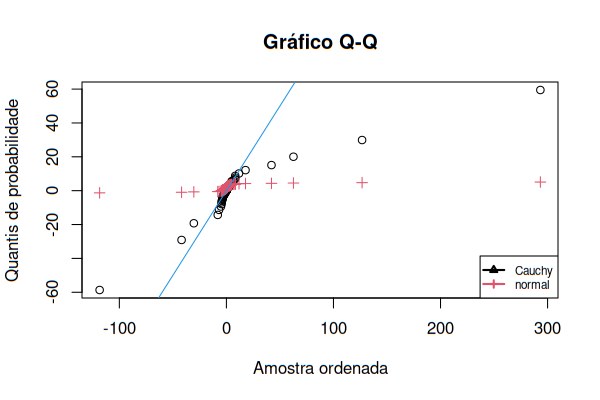

9. Para a construção de intervalos de confiança para o parâmetro $p$ de uma distribuição de Bernoulli podemos recorrer à variável fulcral
   $$Z_1=\frac{\bar{X}-p}{\sqrt{\frac{p(1-p)}{n}}}\stackrel{a}{\sim}N(0,1)$$
   obtida pela aplicação do teorema do limite central a uma amostra aleatória de tamanho $n$ suficientemente grande da referida população. Duas variantes são possíveis:

   **Método 1**

   Usando $Z_1$, não é difícl mostrar que os limites do intervalo de confiança são as soluções da seguinte equação do segundo grau em $p$:
   $$\bar{X}^2-2p\bar{X}+p^2-z^2\frac{p(1-p)}{n}=0,$$
   em que $\bar{X}$ representa a média amostral e $z=\phi^{-1}\left(\frac{1+\gamma}{2}\right)$, para um nível de confiança aproximado $\gamma\in]0,1[$.

   **Método 2**

   Uma segunda aproximação conduz à variável fulcral
   $$Z_2=\frac{\bar{X}-p}{\sqrt{\frac{\bar{X}(1-\bar{X})}{n}}}\stackrel{a}{\sim}N(0,1)$$
   que permite a construção de intervalos de confiança de uma forma mais simples e habitual.

   Com o objetivo de comparar os dois métodos e, em particular, avaliar a adequação da segunda aproximação, implemente os seguintes passos no `R`:
   1. Fixe a semente em $1568$ e para cada valor de $n\in\{30, 50, 100, 200, 300, 500, 1000\}$:
      1. gere $k = 2500$ amostras de tamanho $n$ de uma distribuição de Bernoulli com parâmetro $p = 0.3$;
      2. para cada amostra gerada, calcule a diferença entre os comprimentos dos intervalos de confiança construídos pelo **Método 2** e pelo **Método 1**, com um nível de confiança aproximado $\gamma = 0.97$.
      3. calcule a média das $k = 2500$ diferenças anteriores.
   2. Construa um gráfico que ilustre a variação das diferenças médias em função do tamanho da amostra.

   Submeta um ficheiro em formato PDF, com uma única página A4, que inclua:
   1. O código em `R`.
   2. O gráfico pedido.
   3. Comentários sobre os resultados obtidos.

#### Resolução

   **Método 1**

   As raízes da equação do segundo grau são
   $$\frac{\left(2\bar{X}+\frac{z^2}{n}\right)\pm \sqrt{\left(2\bar{X}+\frac{z^2}{n}\right)^2-4\bar{X}^2\left(1+\frac{z^2}{n}\right)}}{2\left(1+\frac{z^2}{n}\right)}$$
   e o comprimento do intervalo de confiança é igual a $\frac{ \sqrt{\left(2\bar{X}+\frac{z^2}{n}\right)^2-4\bar{X}^2\left(1+\frac{z^2}{n}\right)}}{\left(1+\frac{z^2}{n}\right)}$.

   **Método 2**

   O intervalo de confiança tem a expressão $\left[\bar{X}-z\sqrt{\frac{\bar{X}(1-\bar{X})}{n}}, \bar{X}+z\sqrt{\frac{\bar{X}(1-\bar{X})}{n}}\right]$ e um comprimento igual a $2z\sqrt{\frac{\bar{X}(1-\bar{X})}{n}}$.

   *Nota:* nas expressões anteriores, $z$ representa um quantil adequado da distribuição normal reduzida.

   ```
   # seed <- 435 # por exemplo
   # k <- 2000
   # p <- 0.5
   # gama <- 0.95

   library(ggplot2)
   set.seed(seed)

   tam <- c(30, 50, 100, 200, 300, 500, 1000)
   z <- qnorm((1 + gama) / 2)
   c1 <- vector(length = k)
   c2 <- vector(length = k)
   res <- data.frame()
   for(n in tam) {
     for(i in 1:k) {
       amostra <- rbinom(n, 1, p)
       media <- mean(amostra)
       c1[i] <- sqrt((2 * media + z^2 / n)^2 - 4 * media^2 * (1 + z^2 / n)) / (1 + z^2 / n)
       c2[i] <- 2 * z * sqrt(media * (1 - media) / n)
     }
     res <- rbind(res, c(n, mean(c2 - c1)))
   }
   names(res) <- c("n", "d")

   ggplot(res) +
     geom_line(aes(n,  d), color = "lightblue") +
     geom_point(aes(n, d), color = "magenta") +
     labs(title = "Comparação de dois métodos de construção de IC\npara o parâmetro de uma população de Bernoulli",
          x = 'Tamanho da amostra',
          y = 'Diferença média dos comprimentos dos IC') +
     theme_linedraw()
   ```

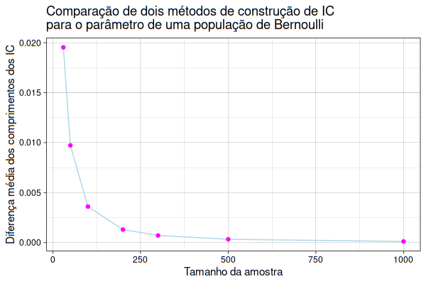

10. Considere uma variável aleatória $X$ com distribuição Normal de valor esperado $\mu$ desconhecido e variância $\sigma^2=15.2$. Construa um teste de hipóteses $H_0:\mu= 77.3$ contra $H_1:\mu\neq77.3$, ao nível de significância de $\alpha = 0.06$.

    Com recurso ao `R` e fixando a semente em $1180$, gere $m=200$ amostras de dimensão $n=26$ dessa variável, admitindo que $\mu = 78.3$. Aplique o teste de hipóteses que construiu para cada amostra gerada, e use o conjunto de resultados para obter uma estimativa da probabilidade do teste conduzir à não rejeição de $H_0$. Indique o resultado com 3 casas decimais.

#### Resolução

    ```
    # seed <- 337 # por exemplo
    # n <- 32
    # m <- 250
    # m0 <- 29.6
    # m1 <- 31
    # sigma2 <- 4
    # alpha <- 0.03

    set.seed(seed)

    quant <- qnorm(1 - alpha / 2)

    res <- 0
    for (i in 1:m){
      amostra <- rnorm(n, mean = m1, sd = sqrt(sigma2))
      valorabs <- abs(sqrt(n) * (mean(amostra) - m0) / sqrt(sigma2))
      res <- res + (valorabs <= quant)
    }
    res <- res / m
    ```

    A estimativa da probabilidade do teste conduzir à não rejeição de $H_0:\mu = 77.3$ quando o valor esperado da variável aleatória é $\mu = 78.3$ é 0.755.